# Introdução ao R

Cristiane Taniguti

July 25, 2017

Esse material foi elaborado para o *Minicurso de Introdução ao R e Aplicações no Melhoramento de Plantas*. O minicurso foi ministrado pelos alunos de pós-graduação do Programa de Genética e Melhoramento de Plantas da ESALQ (USP).

Você pode acessar os outros materiais elaborados para o minicurso [aqui](http://cristianetaniguti.github.io/Workshop_genetica_esalq/).

# 1 Instalação R e RStudio

O R está diponível para os sistemas operacionais Linux, Mac e Windows. Aqui descreveremos os passos necessários para instalação no sistema Linux. Para instruções detalhadas de como instalar para qualquer um dos sistemas acesse o [site do CRAN](https://cran.r-project.org/):

## 1.1 Instalação do R no Ubuntu 16.04

O primeiro passo para a instalação é procurar pelo arquivo `sources.list` e adicionar à ele o caminho para o “espelho” do R de sua preferência (veja as opções [aqui](https://cran.r-project.org/mirrors.html)) e a distribuição Linux referente ao seu sistema. Normalmente, o arquivo esta localizado em:

```bash
cd /etc/apt/
```

Pode ser que o arquivo esteja com permissão apenas para leitura para os usuários comuns, portanto acesse-o como super usuário utilizando um editor de texto de sua preferência e adicione o caminho. Exemplo:

```bash
sudo nano sources.list
```

Aqui consideraremos a distribuição Linux xenial (correspondente à Ubuntu 16.04) e escolheremos o espelho localizado na ESALQ, portanto adicionamos a linha:

```
#deb https://brieger.esalq.usp.br/CRAN/bin/linux/ubuntu xenial/
```

A partir disso basta seguir os comandos:

```bash
sudo update
sudo apt-get install r-base
sudo apt-get install r-base-dev
```

Abrindo o R você verá algo como:

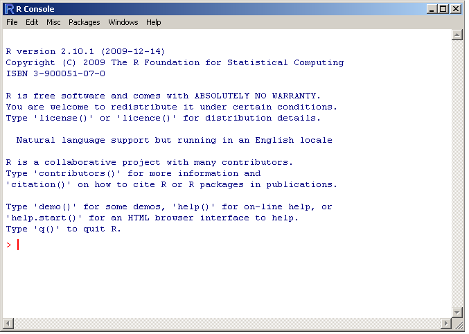

## 1.2 Instalação do RStudio

O RStudio é uma interface mais amigável do R, com funcionalidades muito práticas. A interface do RStudio também esta disponível para os sistemas Windows, Mac e Linux. Para qualquer um deles, selecione o arquivo correspondente no [site](https://www.rstudio.com/products/rstudio/download/).

No caso de um sistema linux, o arquivo baixado terá extenção `.deb`(para Ubuntu) ou `.rpm`(para Fedora) e basta clicar duas vezes no arquivo que o gerenciador de pacotes do Linux iniciará a instalação.

## 1.3 Familiarização com a interface do RStudio

A interface é separada em quatro janelas com principais funções:

- Edição de código
- Ambiente de trabalho e histórico
- Console
- Arquivos, gráficos, pacotes e ajuda

Explore cada uma das janelas. São inumeras funcionalidades para cada uma delas, exploraremos algumas delas a seguir.

Utilize a janela de edição de código (provavelmente a localizada no canto superior esquerdo) para escrever o seu código e salve o arquivo com o nome que desejar com terminação `.R`. Aperte o botão `Run` para processar cada linha do código ou use `Ctrl + enter`.

# 2 Operações básicas

Vamos então à linguagem!

O R pode funcionar como uma simples **calculadora**, que utiliza a mesma sintaxe que outros programas (como o excel):

```r
1+1
2*3
2^3
4/2

sqrt(4)
log(100, base = 10)
log(100)
```

Para organizar o seu código é uma ótima prática fazer **comentários** nele, para que você possa se lembrar mais tarde do que estava pensando no momento ou para que outras pessoas possam entendê-lo. Para isso, use `#` para que o R entenda que trata-se de apenas um comentário, como no exemplo:

```r
#########################
# Script da Prática Básica
# do minicurso "Introdução ao R"

# Data: 25/07/2017
# Cristiane Taniguti
##########################

# Operações básicas

1+1.4               #Decimal definido com "."
2*3
2^3
4/2

sqrt(4)             #raíz quadrada
log(100, base = 10) #logarítmo na base 10
log(100)            #logarítmo com base neperiana
```

Agora, utilize as operações básicas para solucionar expressão:

$(\frac{13+2+1.5}{3})+ log_{4}96$

Resultado esperado:

```
## [1] 8.792481
```

Os comandos `log` e `sqrt` são duas de muitas outras funções básicas que o R possui. Para todas elas o R possui uma descrição para auxiliar no seu uso, para acessar essa ajuda use:

```r
?log
```

E será aberta a descrição da função na janela `Help` do RStudio.

Se a descrição do próprio R não for suficiente para você entender como funciona a função, busque no google (de preferência em inglês). Existem diversos sites e fóruns com informações didáticas das funções do R.

## 2.1 Operações com vetores

Os vetores são as estruturas mais simples trabalhadas no R. Construímos um vetor com uma sequencia numérica usando:

```r
c(1,3,2,5,2)
```

```
## [1] 1 3 2 5 2
```

Podemos utilizar outras funções para gerar sequencias, como:

```r
seq(from=0, to=100, by=5)
```

```
##  [1]   0   5  10  15  20  25  30  35  40  45  50  55  60  65  70  75  80
## [18]  85  90  95 100
```

```r
# ou
seq(0,100,5) # Se você já souber a ordem dos argumentos da função
```

```
##  [1]   0   5  10  15  20  25  30  35  40  45  50  55  60  65  70  75  80
## [18]  85  90  95 100
```

- Crie uma sequencia utilizando a função `seq` que varie de 4 a 30, com intervalos de 3 em 3.

```r
seq(from=4, to=30, by=3)
```

```
## [1]  4  7 10 13 16 19 22 25 28
```

A função `rep` gera sequencias com números repetidos:

```r
rep(3:5, 2)
```

```
## [1] 3 4 5 3 4 5
```

Podemos realizar operações utilizando esses vetores:

```r
c(1,4,3,2,5,8)*2
c(4,2,1,5,3,2)+c(5,2,6,1,3,5)
c(4,2,1,5,3,2)*c(5,2,6,1,3,5)
```

Repare que já esta ficando cansativo digitar os mesmos números repetidamente, vamos resolver isso criando **objetos** para armazenar nossos vetores e muito mais.

# 3 Criando objetos

O armazenamento de informações em objetos e a possível manipulação desses faz do R uma linguagem *orientada por objetos*. Para criar um objeto basta atribuir valores para variáveis como a seguir:

```r
x = c(30.1,30.4,40,30.2,30.6,40.1)
# ou
x <- c(30.1,30.4,40,30.2,30.6,40.1)

y = c(0.26,0.3,0.36,0.24,0.27,0.35)
```

Os mais antigos costumam usar o sinal `<-`, mas tem a mesma função de `=`. Escolha usar o qual preferir.

Para acessar os valores dentro o objeto basta:

```r
x
```

```
## [1] 30.1 30.4 40.0 30.2 30.6 40.1
```

A linguagem é sensível à letras maiúsculas e minúsculas, portanto `x` é diferente de `X`:

```r
X
```

O objeto `X` não foi criado.

Podemos então realizar as operações com o objeto criado:

```r
x*2
x + y
x*y
```

E podemos armazenar a operação em outro objeto:

```r
z <- (x+y)/2
z
```

Podemos também aplicar algumas funções, como exemplo:

```r
sum(z)  # soma dos valores de z
```

```
## [1] 101.59
```

```r
mean(z) # média
```

```
## [1] 16.93167
```

```r
var(z)  # variância
```

```
## [1] 6.427507
```

Acessamos somente o 3º valor do vetor criado com `[]`:

```r
z[3]
```

Também podemos acessar o número da posição 2 a 4 com:

```r
z[2:4]
```

```
## [1] 15.35 20.18 15.22
```

Para obter informações do vetor criado utilize:

```r
str(z)
```

```
##  num [1:6] 15.2 15.3 20.2 15.2 15.4 ...
```

A função `str` nos diz sobre a estrutura do vetor, que se trata de um vetor **numérico** com 6 elementos.

Os vetores também podem receber outras categorias como **caracteres**:

```r
clone <- c("GRA02", "URO01", "URO03", "GRA02", "GRA01", "URO01")
```

Outra classe são os **fatores**, esses podem ser um pouco complexos de lidar. Agora no início, é bom evitá-los a não ser que esteja trabalhando com modelos estatísticos (como faremos em outra prática).

De forma geral, fatores são valores categorizados por `levels`, como exemplo, se transformarmos nosso vetor de caracteres `clone` em fator, serão atribuidos níveis para cada uma das palavras:

```r
clone_fator <- as.factor(clone)
str(clone_fator)
```

```
##  Factor w/ 4 levels "GRA01","GRA02",..: 2 3 4 2 1 3
```

Dessa forma, teremos apenas 4 níveis para um vetor com 6 elementos, já que as palavras “GRA02” e “URO01” se repetem. Podemos obter o número de elementos do vetor ou o seu comprimento com:

```r
length(clone_fator)
```

```
## [1] 6
```

Também vetores **lógicos**, que recebem valores de verdadeiro ou falso:

```r
logical <- x > 40
logical   # Os elementos são maiores que 40?
```

```
## [1] FALSE FALSE FALSE FALSE FALSE  TRUE
```

Com ele podemos, por exemplo, identificar quais são as posições dos elementos maiores que 40:

```r
which(logical)  # Obtendo as posiçoes dos elementos TRUE
```

```
## [1] 6
```

```r
x[which(logical)] # Obtendo os números maiores que 40 do vetor z pela posição
```

```
## [1] 40.1
```

Encontre mais sobre outros operadores lógicos, como o `>` utilizado, neste [link](http://www.statmethods.net/management/operators.html).

Não é possível misturar diferentes classes dentro de um mesmo vetor, ao tentar fazer isso repare que o R irá tentar igualar para uma única classe:

```r
errado <- c(TRUE, "vish", 1)
errado
```

```
## [1] "TRUE" "vish" "1"
```

No caso, todos os elementos foram transformados em caracter.